# Risk Factor Analysis

## Outcome Variable

**Outcome Variable:** ever_wasted

## Predictor Variables

**Intervention Variable:** gagebrth

**Adjustment Set:**

- arm
- sex
- W_mage
- meducyrs
- feducyrs
- hhwealth_quart
- W_nrooms
- W_nchldlt5
- brthmon
- W_parity
- impsan
- delta_W_mage
- delta_meducyrs
- delta_feducyrs
- delta_hhwealth_quart
- delta_W_nrooms
- delta_W_nchldlt5
- delta_brthmon
- delta_W_parity
- delta_impsan

## Stratifying Variables

The analysis was stratified on these variable(s):

- agecat
- studyid
- country

## Data Summary

| agecat | studyid | country | gagebrth | ever_wasted | n_cell | n |
| --- | --- | --- | --- | --- | --- | --- |
| 0-24 months (no birth wast) | CMC-V-BCS-2002 | INDIA | Full or late term | 0 | 123 | 348 |
| 0-24 months (no birth wast) | CMC-V-BCS-2002 | INDIA | Full or late term | 1 | 90 | 348 |
| 0-24 months (no birth wast) | CMC-V-BCS-2002 | INDIA | Preterm | 0 | 25 | 348 |
| 0-24 months (no birth wast) | CMC-V-BCS-2002 | INDIA | Preterm | 1 | 27 | 348 |
| 0-24 months (no birth wast) | CMC-V-BCS-2002 | INDIA | Early term | 0 | 46 | 348 |
| 0-24 months (no birth wast) | CMC-V-BCS-2002 | INDIA | Early term | 1 | 37 | 348 |
| 0-24 months (no birth wast) | COHORTS | GUATEMALA | Full or late term | 0 | 394 | 809 |
| 0-24 months (no birth wast) | COHORTS | GUATEMALA | Full or late term | 1 | 54 | 809 |
| 0-24 months (no birth wast) | COHORTS | GUATEMALA | Preterm | 0 | 105 | 809 |
| 0-24 months (no birth wast) | COHORTS | GUATEMALA | Preterm | 1 | 25 | 809 |
| 0-24 months (no birth wast) | COHORTS | GUATEMALA | Early term | 0 | 191 | 809 |
| 0-24 months (no birth wast) | COHORTS | GUATEMALA | Early term | 1 | 40 | 809 |
| 0-24 months (no birth wast) | COHORTS | INDIA | Full or late term | 0 | 470 | 1345 |
| 0-24 months (no birth wast) | COHORTS | INDIA | Full or late term | 1 | 109 | 1345 |
| 0-24 months (no birth wast) | COHORTS | INDIA | Preterm | 0 | 242 | 1345 |
| 0-24 months (no birth wast) | COHORTS | INDIA | Preterm | 1 | 66 | 1345 |
| 0-24 months (no birth wast) | COHORTS | INDIA | Early term | 0 | 358 | 1345 |
| 0-24 months (no birth wast) | COHORTS | INDIA | Early term | 1 | 100 | 1345 |
| 0-24 months (no birth wast) | COHORTS | PHILIPPINES | Full or late term | 0 | 830 | 2993 |
| 0-24 months (no birth wast) | COHORTS | PHILIPPINES | Full or late term | 1 | 328 | 2993 |
| 0-24 months (no birth wast) | COHORTS | PHILIPPINES | Preterm | 0 | 434 | 2993 |
| 0-24 months (no birth wast) | COHORTS | PHILIPPINES | Preterm | 1 | 199 | 2993 |
| 0-24 months (no birth wast) | COHORTS | PHILIPPINES | Early term | 0 | 822 | 2993 |
| 0-24 months (no birth wast) | COHORTS | PHILIPPINES | Early term | 1 | 380 | 2993 |
| 0-24 months (no birth wast) | IRC | INDIA | Full or late term | 0 | 121 | 389 |
| 0-24 months (no birth wast) | IRC | INDIA | Full or late term | 1 | 128 | 389 |
| 0-24 months (no birth wast) | IRC | INDIA | Preterm | 0 | 16 | 389 |
| 0-24 months (no birth wast) | IRC | INDIA | Preterm | 1 | 26 | 389 |
| 0-24 months (no birth wast) | IRC | INDIA | Early term | 0 | 44 | 389 |
| 0-24 months (no birth wast) | IRC | INDIA | Early term | 1 | 54 | 389 |

[output cut: 150 more lines]

The following strata were considered:

- agecat: 0-24 months (no birth wast), studyid: CMC-V-BCS-2002, country: INDIA
- agecat: 0-24 months (no birth wast), studyid: COHORTS, country: GUATEMALA
- agecat: 0-24 months (no birth wast), studyid: COHORTS, country: INDIA
- agecat: 0-24 months (no birth wast), studyid: COHORTS, country: PHILIPPINES
- agecat: 0-24 months (no birth wast), studyid: IRC, country: INDIA
- agecat: 0-24 months (no birth wast), studyid: JiVitA-3, country: BANGLADESH
- agecat: 0-24 months (no birth wast), studyid: Keneba, country: GAMBIA
- agecat: 0-24 months (no birth wast), studyid: NIH-Crypto, country: BANGLADESH
- agecat: 0-24 months (no birth wast), studyid: PROBIT, country: BELARUS
- agecat: 0-24 months (no birth wast), studyid: TanzaniaChild2, country: TANZANIA, UNITED REPUBLIC OF
- agecat: 0-6 months (no birth wast), studyid: CMC-V-BCS-2002, country: INDIA
- agecat: 0-6 months (no birth wast), studyid: COHORTS, country: GUATEMALA
- agecat: 0-6 months (no birth wast), studyid: COHORTS, country: INDIA
- agecat: 0-6 months (no birth wast), studyid: COHORTS, country: PHILIPPINES
- agecat: 0-6 months (no birth wast), studyid: IRC, country: INDIA
- agecat: 0-6 months (no birth wast), studyid: JiVitA-3, country: BANGLADESH
- agecat: 0-6 months (no birth wast), studyid: Keneba, country: GAMBIA
- agecat: 0-6 months (no birth wast), studyid: NIH-Crypto, country: BANGLADESH
- agecat: 0-6 months (no birth wast), studyid: PROBIT, country: BELARUS
- agecat: 0-6 months (no birth wast), studyid: TanzaniaChild2, country: TANZANIA, UNITED REPUBLIC OF
- agecat: 6-24 months, studyid: CMC-V-BCS-2002, country: INDIA
- agecat: 6-24 months, studyid: COHORTS, country: GUATEMALA
- agecat: 6-24 months, studyid: COHORTS, country: INDIA
- agecat: 6-24 months, studyid: COHORTS, country: PHILIPPINES
- agecat: 6-24 months, studyid: IRC, country: INDIA
- agecat: 6-24 months, studyid: JiVitA-3, country: BANGLADESH
- agecat: 6-24 months, studyid: Keneba, country: GAMBIA
- agecat: 6-24 months, studyid: NIH-Crypto, country: BANGLADESH
- agecat: 6-24 months, studyid: PROBIT, country: BELARUS
- agecat: 6-24 months, studyid: TanzaniaChild2, country: TANZANIA, UNITED REPUBLIC OF

### Dropped Strata

Some strata were dropped due to rare outcomes:

- agecat: 0-6 months (no birth wast), studyid: COHORTS, country: GUATEMALA

## Methods Detail

We’re interested in the causal parameters $E[Y_a]$ for all values of $a \in \mathcal{A}$. These parameters represent the mean outcome if, possibly contrary to fact, we intervened to set all units to have $A=a$. Under the randomization and positivity assumptions, these are identified by the statistical parameters $\psi_a=E_W[E_{Y|A,W}(Y|A=a,W)]$. In addition, we’re interested in the mean of $Y$, $E[Y]$ under no intervention (the observed mean). We will estimate these parameters by using SuperLearner to fit the relevant likelihood factors – $E_{Y|A,W}(Y|A=a,W)$ and $p(A=a|W)$, and then updating our likelihood fit using a joint TMLE.

For unadjusted analyses ($W=\{\}$), initial likelihoods were estimated using Lrnr_glm to estimate the simple $E(Y|A)$ and Lrnr_mean to estimate $p(A)$. For adjusted analyses, a small library containing Lrnr_glmnet, Lrnr_xgboost, and Lrnr_mean was used.

Having estimated these parameters, we will then use the delta method to estimate relative risks and attributable risks relative to a prespecified baseline level of $A$.

# Results Detail

## Results Plots

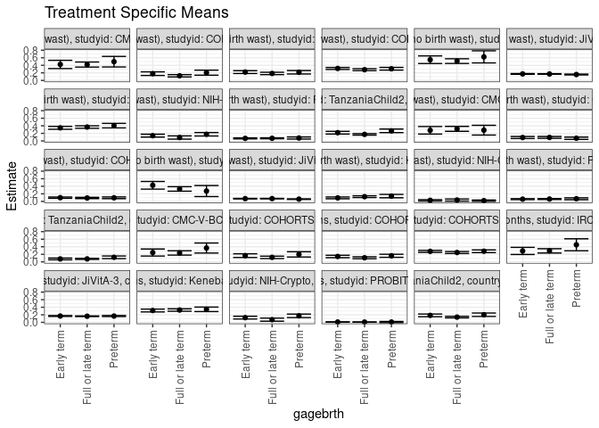

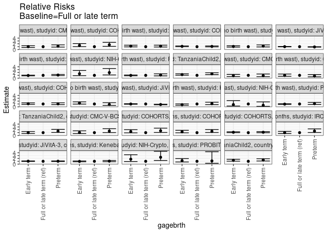

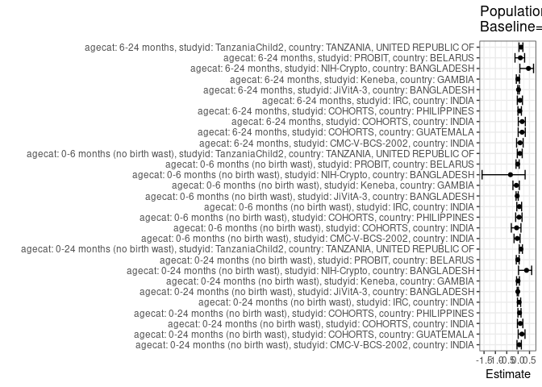

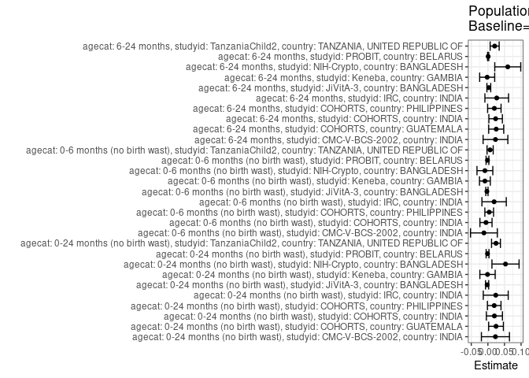

## Results Table

### Parameter: TSM

| agecat | studyid | country | intervention_level | baseline_level | estimate | ci_lower | ci_upper |
| --- | --- | --- | --- | --- | --- | --- | --- |
| 0-24 months (no birth wast) | CMC-V-BCS-2002 | INDIA | Full or late term | NA | 0.4198278 | 0.3530764 | 0.4865792 |
| 0-24 months (no birth wast) | CMC-V-BCS-2002 | INDIA | Preterm | NA | 0.4958663 | 0.3557954 | 0.6359371 |
| 0-24 months (no birth wast) | CMC-V-BCS-2002 | INDIA | Early term | NA | 0.4228433 | 0.3138497 | 0.5318368 |
| 0-24 months (no birth wast) | COHORTS | GUATEMALA | Full or late term | NA | 0.1225908 | 0.0922922 | 0.1528894 |
| 0-24 months (no birth wast) | COHORTS | GUATEMALA | Preterm | NA | 0.2046738 | 0.1381041 | 0.2712435 |
| 0-24 months (no birth wast) | COHORTS | GUATEMALA | Early term | NA | 0.1789315 | 0.1308899 | 0.2269732 |
| 0-24 months (no birth wast) | COHORTS | INDIA | Full or late term | NA | 0.1848926 | 0.1532597 | 0.2165256 |
| 0-24 months (no birth wast) | COHORTS | INDIA | Preterm | NA | 0.2156916 | 0.1705503 | 0.2608329 |
| 0-24 months (no birth wast) | COHORTS | INDIA | Early term | NA | 0.2203702 | 0.1828724 | 0.2578680 |
| 0-24 months (no birth wast) | COHORTS | PHILIPPINES | Full or late term | NA | 0.2840153 | 0.2581083 | 0.3099223 |
| 0-24 months (no birth wast) | COHORTS | PHILIPPINES | Preterm | NA | 0.3082596 | 0.2724599 | 0.3440593 |
| 0-24 months (no birth wast) | COHORTS | PHILIPPINES | Early term | NA | 0.3164987 | 0.2903689 | 0.3426284 |
| 0-24 months (no birth wast) | IRC | INDIA | Full or late term | NA | 0.5110549 | 0.4487892 | 0.5733207 |
| 0-24 months (no birth wast) | IRC | INDIA | Preterm | NA | 0.6230981 | 0.4625355 | 0.7836608 |
| 0-24 months (no birth wast) | IRC | INDIA | Early term | NA | 0.5476192 | 0.4467721 | 0.6484663 |
| 0-24 months (no birth wast) | JiVitA-3 | BANGLADESH | Full or late term | NA | 0.1709036 | 0.1637530 | 0.1780541 |
| 0-24 months (no birth wast) | JiVitA-3 | BANGLADESH | Preterm | NA | 0.1558704 | 0.1451345 | 0.1666062 |
| 0-24 months (no birth wast) | JiVitA-3 | BANGLADESH | Early term | NA | 0.1721128 | 0.1622813 | 0.1819443 |
| 0-24 months (no birth wast) | Keneba | GAMBIA | Full or late term | NA | 0.3669604 | 0.3344992 | 0.3994215 |
| 0-24 months (no birth wast) | Keneba | GAMBIA | Preterm | NA | 0.4040634 | 0.3441599 | 0.4639669 |
| 0-24 months (no birth wast) | Keneba | GAMBIA | Early term | NA | 0.3458593 | 0.3076544 | 0.3840641 |
| 0-24 months (no birth wast) | NIH-Crypto | BANGLADESH | Full or late term | NA | 0.0901651 | 0.0468783 | 0.1334518 |
| 0-24 months (no birth wast) | NIH-Crypto | BANGLADESH | Preterm | NA | 0.1760255 | 0.1299945 | 0.2220564 |
| 0-24 months (no birth wast) | NIH-Crypto | BANGLADESH | Early term | NA | 0.1390526 | 0.1013726 | 0.1767327 |
| 0-24 months (no birth wast) | PROBIT | BELARUS | Full or late term | NA | 0.0690484 | 0.0565333 | 0.0815636 |
| 0-24 months (no birth wast) | PROBIT | BELARUS | Preterm | NA | 0.0764671 | 0.0487171 | 0.1042171 |
| 0-24 months (no birth wast) | PROBIT | BELARUS | Early term | NA | 0.0669893 | 0.0541588 | 0.0798199 |
| 0-24 months (no birth wast) | TanzaniaChild2 | TANZANIA, UNITED REPUBLIC OF | Full or late term | NA | 0.1732033 | 0.1532543 | 0.1931523 |
| 0-24 months (no birth wast) | TanzaniaChild2 | TANZANIA, UNITED REPUBLIC OF | Preterm | NA | 0.2665361 | 0.2197249 | 0.3133473 |
| 0-24 months (no birth wast) | TanzaniaChild2 | TANZANIA, UNITED REPUBLIC OF | Early term | NA | 0.2170690 | 0.1812791 | 0.2528590 |

[output cut: 57 more lines]

### Parameter: E(Y)

| agecat | studyid | country | intervention_level | baseline_level | estimate | ci_lower | ci_upper |
| --- | --- | --- | --- | --- | --- | --- | --- |
| 0-24 months (no birth wast) | CMC-V-BCS-2002 | INDIA | NA | NA | 0.4425287 | 0.3902692 | 0.4947882 |
| 0-24 months (no birth wast) | COHORTS | GUATEMALA | NA | NA | 0.1470952 | 0.1226726 | 0.1715178 |
| 0-24 months (no birth wast) | COHORTS | INDIA | NA | NA | 0.2044610 | 0.1828992 | 0.2260227 |
| 0-24 months (no birth wast) | COHORTS | PHILIPPINES | NA | NA | 0.3030404 | 0.2865732 | 0.3195077 |
| 0-24 months (no birth wast) | IRC | INDIA | NA | NA | 0.5347044 | 0.4850733 | 0.5843354 |
| 0-24 months (no birth wast) | JiVitA-3 | BANGLADESH | NA | NA | 0.1686060 | 0.1631976 | 0.1740145 |
| 0-24 months (no birth wast) | Keneba | GAMBIA | NA | NA | 0.3658392 | 0.3428819 | 0.3887966 |
| 0-24 months (no birth wast) | NIH-Crypto | BANGLADESH | NA | NA | 0.1432361 | 0.1182149 | 0.1682572 |
| 0-24 months (no birth wast) | PROBIT | BELARUS | NA | NA | 0.0680135 | 0.0562135 | 0.0798135 |
| 0-24 months (no birth wast) | TanzaniaChild2 | TANZANIA, UNITED REPUBLIC OF | NA | NA | 0.1975914 | 0.1811057 | 0.2140772 |
| 0-6 months (no birth wast) | CMC-V-BCS-2002 | INDIA | NA | NA | 0.3072289 | 0.2575285 | 0.3569293 |
| 0-6 months (no birth wast) | COHORTS | INDIA | NA | NA | 0.0864692 | 0.0708761 | 0.1020623 |
| 0-6 months (no birth wast) | COHORTS | PHILIPPINES | NA | NA | 0.0942127 | 0.0837084 | 0.1047169 |
| 0-6 months (no birth wast) | IRC | INDIA | NA | NA | 0.3477089 | 0.2991827 | 0.3962350 |
| 0-6 months (no birth wast) | JiVitA-3 | BANGLADESH | NA | NA | 0.0703622 | 0.0666948 | 0.0740296 |
| 0-6 months (no birth wast) | Keneba | GAMBIA | NA | NA | 0.1156550 | 0.0998052 | 0.1315047 |
| 0-6 months (no birth wast) | NIH-Crypto | BANGLADESH | NA | NA | 0.0267023 | 0.0151493 | 0.0382553 |
| 0-6 months (no birth wast) | PROBIT | BELARUS | NA | NA | 0.0612233 | 0.0502388 | 0.0722078 |
| 0-6 months (no birth wast) | TanzaniaChild2 | TANZANIA, UNITED REPUBLIC OF | NA | NA | 0.0859445 | 0.0743193 | 0.0975697 |
| 6-24 months | CMC-V-BCS-2002 | INDIA | NA | NA | 0.2592593 | 0.2133485 | 0.3051700 |
| 6-24 months | COHORTS | GUATEMALA | NA | NA | 0.1443433 | 0.1194882 | 0.1691984 |
| 6-24 months | COHORTS | INDIA | NA | NA | 0.1318764 | 0.1136647 | 0.1500881 |
| 6-24 months | COHORTS | PHILIPPINES | NA | NA | 0.2669537 | 0.2505274 | 0.2833801 |
| 6-24 months | IRC | INDIA | NA | NA | 0.3179487 | 0.2716722 | 0.3642252 |
| 6-24 months | JiVitA-3 | BANGLADESH | NA | NA | 0.1648358 | 0.1585302 | 0.1711415 |
| 6-24 months | Keneba | GAMBIA | NA | NA | 0.3241590 | 0.3014644 | 0.3468537 |
| 6-24 months | NIH-Crypto | BANGLADESH | NA | NA | 0.1315068 | 0.1069744 | 0.1560393 |
| 6-24 months | PROBIT | BELARUS | NA | NA | 0.0083745 | 0.0044130 | 0.0123360 |
| 6-24 months | TanzaniaChild2 | TANZANIA, UNITED REPUBLIC OF | NA | NA | 0.1591987 | 0.1427306 | 0.1756669 |

### Parameter: RR

| agecat | studyid | country | intervention_level | baseline_level | estimate | ci_lower | ci_upper |
| --- | --- | --- | --- | --- | --- | --- | --- |
| 0-24 months (no birth wast) | CMC-V-BCS-2002 | INDIA | Full or late term | Full or late term | 1.0000000 | 1.0000000 | 1.0000000 |
| 0-24 months (no birth wast) | CMC-V-BCS-2002 | INDIA | Preterm | Full or late term | 1.1811182 | 0.8534728 | 1.6345457 |
| 0-24 months (no birth wast) | CMC-V-BCS-2002 | INDIA | Early term | Full or late term | 1.0071826 | 0.7434810 | 1.3644153 |
| 0-24 months (no birth wast) | COHORTS | GUATEMALA | Full or late term | Full or late term | 1.0000000 | 1.0000000 | 1.0000000 |
| 0-24 months (no birth wast) | COHORTS | GUATEMALA | Preterm | Full or late term | 1.6695686 | 1.1104908 | 2.5101146 |
| 0-24 months (no birth wast) | COHORTS | GUATEMALA | Early term | Full or late term | 1.4595836 | 1.0139597 | 2.1010543 |
| 0-24 months (no birth wast) | COHORTS | INDIA | Full or late term | Full or late term | 1.0000000 | 1.0000000 | 1.0000000 |
| 0-24 months (no birth wast) | COHORTS | INDIA | Preterm | Full or late term | 1.1665776 | 0.8910887 | 1.5272368 |
| 0-24 months (no birth wast) | COHORTS | INDIA | Early term | Full or late term | 1.1918819 | 0.9375157 | 1.5152627 |
| 0-24 months (no birth wast) | COHORTS | PHILIPPINES | Full or late term | Full or late term | 1.0000000 | 1.0000000 | 1.0000000 |
| 0-24 months (no birth wast) | COHORTS | PHILIPPINES | Preterm | Full or late term | 1.0853626 | 0.9366429 | 1.2576959 |
| 0-24 months (no birth wast) | COHORTS | PHILIPPINES | Early term | Full or late term | 1.1143719 | 0.9857473 | 1.2597800 |
| 0-24 months (no birth wast) | IRC | INDIA | Full or late term | Full or late term | 1.0000000 | 1.0000000 | 1.0000000 |
| 0-24 months (no birth wast) | IRC | INDIA | Preterm | Full or late term | 1.2192391 | 0.9166196 | 1.6217675 |
| 0-24 months (no birth wast) | IRC | INDIA | Early term | Full or late term | 1.0715466 | 0.8591271 | 1.3364869 |
| 0-24 months (no birth wast) | JiVitA-3 | BANGLADESH | Full or late term | Full or late term | 1.0000000 | 1.0000000 | 1.0000000 |
| 0-24 months (no birth wast) | JiVitA-3 | BANGLADESH | Preterm | Full or late term | 0.9120370 | 0.8438835 | 0.9856947 |
| 0-24 months (no birth wast) | JiVitA-3 | BANGLADESH | Early term | Full or late term | 1.0070756 | 0.9402600 | 1.0786391 |
| 0-24 months (no birth wast) | Keneba | GAMBIA | Full or late term | Full or late term | 1.0000000 | 1.0000000 | 1.0000000 |
| 0-24 months (no birth wast) | Keneba | GAMBIA | Preterm | Full or late term | 1.1011091 | 0.9267194 | 1.3083155 |
| 0-24 months (no birth wast) | Keneba | GAMBIA | Early term | Full or late term | 0.9424976 | 0.8184929 | 1.0852895 |
| 0-24 months (no birth wast) | NIH-Crypto | BANGLADESH | Full or late term | Full or late term | 1.0000000 | 1.0000000 | 1.0000000 |
| 0-24 months (no birth wast) | NIH-Crypto | BANGLADESH | Preterm | Full or late term | 1.9522581 | 1.1294288 | 3.3745481 |
| 0-24 months (no birth wast) | NIH-Crypto | BANGLADESH | Early term | Full or late term | 1.5422006 | 0.8880985 | 2.6780618 |
| 0-24 months (no birth wast) | PROBIT | BELARUS | Full or late term | Full or late term | 1.0000000 | 1.0000000 | 1.0000000 |
| 0-24 months (no birth wast) | PROBIT | BELARUS | Preterm | Full or late term | 1.1074412 | 0.8064841 | 1.5207071 |
| 0-24 months (no birth wast) | PROBIT | BELARUS | Early term | Full or late term | 0.9701787 | 0.8468017 | 1.1115314 |
| 0-24 months (no birth wast) | TanzaniaChild2 | TANZANIA, UNITED REPUBLIC OF | Full or late term | Full or late term | 1.0000000 | 1.0000000 | 1.0000000 |
| 0-24 months (no birth wast) | TanzaniaChild2 | TANZANIA, UNITED REPUBLIC OF | Preterm | Full or late term | 1.5388630 | 1.2473468 | 1.8985092 |
| 0-24 months (no birth wast) | TanzaniaChild2 | TANZANIA, UNITED REPUBLIC OF | Early term | Full or late term | 1.2532618 | 1.0250941 | 1.5322155 |

[output cut: 57 more lines]

### Parameter: PAR

| agecat | studyid | country | intervention_level | baseline_level | estimate | ci_lower | ci_upper |
| --- | --- | --- | --- | --- | --- | --- | --- |
| 0-24 months (no birth wast) | CMC-V-BCS-2002 | INDIA | Full or late term | NA | 0.0227009 | -0.0195403 | 0.0649422 |
| 0-24 months (no birth wast) | COHORTS | GUATEMALA | Full or late term | NA | 0.0245044 | 0.0022968 | 0.0467119 |
| 0-24 months (no birth wast) | COHORTS | INDIA | Full or late term | NA | 0.0195683 | -0.0046848 | 0.0438215 |
| 0-24 months (no birth wast) | COHORTS | PHILIPPINES | Full or late term | NA | 0.0190251 | -0.0014285 | 0.0394788 |
| 0-24 months (no birth wast) | IRC | INDIA | Full or late term | NA | 0.0236494 | -0.0139235 | 0.0612223 |
| 0-24 months (no birth wast) | JiVitA-3 | BANGLADESH | Full or late term | NA | -0.0022975 | -0.0070640 | 0.0024690 |
| 0-24 months (no birth wast) | Keneba | GAMBIA | Full or late term | NA | -0.0011211 | -0.0241811 | 0.0219389 |
| 0-24 months (no birth wast) | NIH-Crypto | BANGLADESH | Full or late term | NA | 0.0530710 | 0.0121996 | 0.0939424 |
| 0-24 months (no birth wast) | PROBIT | BELARUS | Full or late term | NA | -0.0010349 | -0.0053336 | 0.0032637 |
| 0-24 months (no birth wast) | TanzaniaChild2 | TANZANIA, UNITED REPUBLIC OF | Full or late term | NA | 0.0243882 | 0.0110505 | 0.0377258 |
| 0-6 months (no birth wast) | CMC-V-BCS-2002 | INDIA | Full or late term | NA | -0.0118743 | -0.0523049 | 0.0285563 |
| 0-6 months (no birth wast) | COHORTS | INDIA | Full or late term | NA | -0.0057546 | -0.0239981 | 0.0124889 |
| 0-6 months (no birth wast) | COHORTS | PHILIPPINES | Full or late term | NA | 0.0039649 | -0.0091606 | 0.0170903 |
| 0-6 months (no birth wast) | IRC | INDIA | Full or late term | NA | 0.0187060 | -0.0180010 | 0.0554129 |
| 0-6 months (no birth wast) | JiVitA-3 | BANGLADESH | Full or late term | NA | -0.0029280 | -0.0062729 | 0.0004170 |
| 0-6 months (no birth wast) | Keneba | GAMBIA | Full or late term | NA | -0.0090282 | -0.0253064 | 0.0072500 |
| 0-6 months (no birth wast) | NIH-Crypto | BANGLADESH | Full or late term | NA | -0.0090120 | -0.0328503 | 0.0148263 |
| 0-6 months (no birth wast) | PROBIT | BELARUS | Full or late term | NA | -0.0012182 | -0.0054579 | 0.0030215 |
| 0-6 months (no birth wast) | TanzaniaChild2 | TANZANIA, UNITED REPUBLIC OF | Full or late term | NA | 0.0066808 | -0.0026241 | 0.0159857 |
| 6-24 months | CMC-V-BCS-2002 | INDIA | Full or late term | NA | 0.0228304 | -0.0144432 | 0.0601041 |
| 6-24 months | COHORTS | GUATEMALA | Full or late term | NA | 0.0250372 | 0.0024019 | 0.0476725 |
| 6-24 months | COHORTS | INDIA | Full or late term | NA | 0.0232993 | 0.0029648 | 0.0436338 |
| 6-24 months | COHORTS | PHILIPPINES | Full or late term | NA | 0.0194274 | -0.0007993 | 0.0396540 |
| 6-24 months | IRC | INDIA | Full or late term | NA | 0.0266334 | -0.0089963 | 0.0622632 |
| 6-24 months | JiVitA-3 | BANGLADESH | Full or late term | NA | 0.0027495 | -0.0030438 | 0.0085428 |
| 6-24 months | Keneba | GAMBIA | Full or late term | NA | -0.0021520 | -0.0247904 | 0.0204865 |
| 6-24 months | NIH-Crypto | BANGLADESH | Full or late term | NA | 0.0598276 | 0.0206997 | 0.0989556 |
| 6-24 months | PROBIT | BELARUS | Full or late term | NA | 0.0008264 | -0.0009328 | 0.0025857 |
| 6-24 months | TanzaniaChild2 | TANZANIA, UNITED REPUBLIC OF | Full or late term | NA | 0.0203788 | 0.0068041 | 0.0339536 |

### Parameter: PAF

| agecat | studyid | country | intervention_level | baseline_level | estimate | ci_lower | ci_upper |
| --- | --- | --- | --- | --- | --- | --- | --- |
| 0-24 months (no birth wast) | CMC-V-BCS-2002 | INDIA | Full or late term | NA | 0.0512982 | -0.0492453 | 0.1422072 |
| 0-24 months (no birth wast) | COHORTS | GUATEMALA | Full or late term | NA | 0.1665885 | 0.0032952 | 0.3031289 |
| 0-24 months (no birth wast) | COHORTS | INDIA | Full or late term | NA | 0.0957070 | -0.0309566 | 0.2068087 |
| 0-24 months (no birth wast) | COHORTS | PHILIPPINES | Full or late term | NA | 0.0627808 | -0.0071965 | 0.1278962 |
| 0-24 months (no birth wast) | IRC | INDIA | Full or late term | NA | 0.0442290 | -0.0288185 | 0.1120900 |
| 0-24 months (no birth wast) | JiVitA-3 | BANGLADESH | Full or late term | NA | -0.0136267 | -0.0423055 | 0.0142630 |
| 0-24 months (no birth wast) | Keneba | GAMBIA | Full or late term | NA | -0.0030645 | -0.0681216 | 0.0580300 |
| 0-24 months (no birth wast) | NIH-Crypto | BANGLADESH | Full or late term | NA | 0.3705143 | 0.0190692 | 0.5960447 |
| 0-24 months (no birth wast) | PROBIT | BELARUS | Full or late term | NA | -0.0152167 | -0.0805171 | 0.0461373 |
| 0-24 months (no birth wast) | TanzaniaChild2 | TANZANIA, UNITED REPUBLIC OF | Full or late term | NA | 0.1234272 | 0.0537200 | 0.1879996 |
| 0-6 months (no birth wast) | CMC-V-BCS-2002 | INDIA | Full or late term | NA | -0.0386496 | -0.1788799 | 0.0849001 |
| 0-6 months (no birth wast) | COHORTS | INDIA | Full or late term | NA | -0.0665507 | -0.2995448 | 0.1246702 |
| 0-6 months (no birth wast) | COHORTS | PHILIPPINES | Full or late term | NA | 0.0420842 | -0.1077764 | 0.1716716 |
| 0-6 months (no birth wast) | IRC | INDIA | Full or late term | NA | 0.0537978 | -0.0578995 | 0.1537016 |
| 0-6 months (no birth wast) | JiVitA-3 | BANGLADESH | Full or late term | NA | -0.0416128 | -0.0901595 | 0.0047720 |
| 0-6 months (no birth wast) | Keneba | GAMBIA | Full or late term | NA | -0.0780616 | -0.2281263 | 0.0536667 |
| 0-6 months (no birth wast) | NIH-Crypto | BANGLADESH | Full or late term | NA | -0.3375000 | -1.5855791 | 0.3081216 |
| 0-6 months (no birth wast) | PROBIT | BELARUS | Full or late term | NA | -0.0198978 | -0.0914777 | 0.0469879 |
| 0-6 months (no birth wast) | TanzaniaChild2 | TANZANIA, UNITED REPUBLIC OF | Full or late term | NA | 0.0777334 | -0.0367522 | 0.1795766 |
| 6-24 months | CMC-V-BCS-2002 | INDIA | Full or late term | NA | 0.0880603 | -0.0673566 | 0.2208470 |
| 6-24 months | COHORTS | GUATEMALA | Full or late term | NA | 0.1734559 | 0.0028544 | 0.3148693 |
| 6-24 months | COHORTS | INDIA | Full or late term | NA | 0.1766752 | 0.0079264 | 0.3167203 |
| 6-24 months | COHORTS | PHILIPPINES | Full or late term | NA | 0.0727743 | -0.0061329 | 0.1454931 |
| 6-24 months | IRC | INDIA | Full or late term | NA | 0.0837664 | -0.0353096 | 0.1891469 |
| 6-24 months | JiVitA-3 | BANGLADESH | Full or late term | NA | 0.0166802 | -0.0191262 | 0.0512286 |
| 6-24 months | Keneba | GAMBIA | Full or late term | NA | -0.0066386 | -0.0789566 | 0.0608321 |
| 6-24 months | NIH-Crypto | BANGLADESH | Full or late term | NA | 0.4549393 | 0.0763605 | 0.6783473 |
| 6-24 months | PROBIT | BELARUS | Full or late term | NA | 0.0986856 | -0.1372698 | 0.2856861 |
| 6-24 months | TanzaniaChild2 | TANZANIA, UNITED REPUBLIC OF | Full or late term | NA | 0.1280088 | 0.0391557 | 0.2086453 |